# Classification Algorithms

There are two major types of supervised machine learning problems: classification and regression.

In this workshop we will focus on classification algorithms.

In classification, the goal is to predict a class label, which is a choice from a predefined list of possibilities.

Classification is sometimes separated into binary classification, which is the special case of distinguishing between exactly two classes, and multiclass classification, which is classification between more than two classes. You can think of binary classification as trying to answer a yes/no question.

To start-off lets have a quick look at some classification algorithms.

Disclaimer: This is not an exhaustive list but just some of the algorithms that are popular and that I am familiar with.

# KNeighborsClassifier

In KNeighborsClassifier, K is the number of nearest neighbors. K is the deciding factor. Their are a variety of different ways to find the nearest neighbour. The most common is using Eucliden distance to find the nearest point.

[figure not shown]

Source: [Source: KNN Classification using Scikit-learn](https://www.datacamp.com/community/tutorials/k-nearest-neighbor-classification-scikit-learn)

```python
import numpy as np

# import libraries to plot in the notebook
%matplotlib inline
from matplotlib import pyplot as plt
```

```python
# libraty of helper functions to create data and plots
import mglearn
# generate dataset
X, y = mglearn.datasets.make_forge()
```

```python
print('How many features in X: ', X.shape)
print('How many features in Y: ', y.shape)
```

```
How many features in X:  (26, 2)
How many features in Y:  (26,)
```

This is a very simple dummy data to illustrate how the algorithms is working.

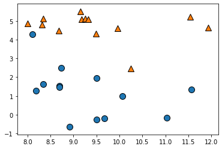

```python
mglearn.discrete_scatter(X[:, 0], X[:, 1], y)
```

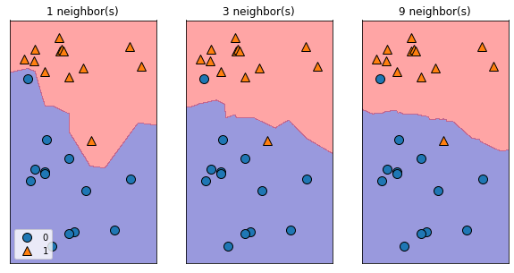

```python
from sklearn.neighbors import KNeighborsClassifier

fig, axes = plt.subplots(1, 3, figsize=(10, 5))


for n_neighbors, ax in zip([1, 3, 9], axes):
    # the fit method returns the object self, so we can instantiate
    # and fit in one line
    clf = KNeighborsClassifier(n_neighbors=n_neighbors).fit(X, y)
    mglearn.plots.plot_2d_separator(clf, X, fill=True, eps=0.5, ax=ax, alpha=.4)
    mglearn.discrete_scatter(X[:, 0], X[:, 1], y, ax=ax )
    ax.set_title("{} neighbor(s)".format(n_neighbors))
    axes[0].legend(loc=3)
```

# Logistic Regression

Logistic regression is a method in which a linear function is passed through a sigmoid function to calculate logits (or scores).

[figure not shown]

Source: [Source: Logistic Regression — Detailed Overview](https://towardsdatascience.com/logistic-regression-detailed-overview-46c4da4303bc)

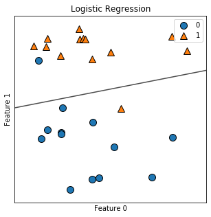

```python
from sklearn.linear_model import LogisticRegression

fig, axes = plt.subplots(1, 1, figsize=(5, 5), )

model = LogisticRegression()

clf = model.fit(X, y)

mglearn.plots.plot_2d_separator(clf, X, fill=False, eps=0.5, ax=axes, alpha=.7)
mglearn.discrete_scatter(X[:, 0], X[:, 1], y, ax=axes)
axes.set_title("Logistic Regression")
axes.set_xlabel("Feature 0")
axes.set_ylabel("Feature 1")
axes.legend()
```

Points above the decision boundary will be predicted as belonging to class "1" while the ones below will be class "0".

A great thing abount Logistic Regression is that it gives you probabilities. The closer your new data point is to a decision boundary the less certainity their is about its class.

If you are interested in probability scores then logistic regression might be a good fit for you.

# Support Vector Machines (SVM)

In SVM, we are looking for a decision boundary that best divides a dataset into two classes.

[figure not shown]

Source: [Source: Support Vector Machines Tutorial – Learn to implement SVM in Python](https://data-flair.training/blogs/svm-support-vector-machine-tutorial/)

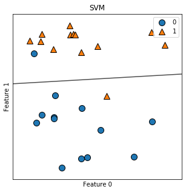

```python
from sklearn.svm import LinearSVC

fig, axes = plt.subplots(1, 1, figsize=(5, 5))

model = LinearSVC()

clf = model.fit(X, y)

mglearn.plots.plot_2d_separator(clf, X, fill=False, eps=0.5, ax=axes, alpha=.7)
mglearn.discrete_scatter(X[:, 0], X[:, 1], y, ax=axes)
axes.set_title("SVM")
axes.set_xlabel("Feature 0")
axes.set_ylabel("Feature 1")
axes.legend()
```

SVM algorithms are not very robust to outliers.

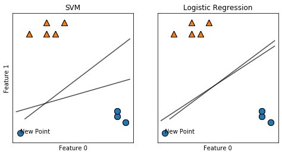

```python
fig, axes = plt.subplots(1, 2, figsize=(8, 4));model = LogisticRegression();clf = model.fit(X_, y_);mglearn.plots.plot_2d_separator(clf, X_, fill=False, eps=0.5, ax=axes[1], alpha=.7)
mglearn.discrete_scatter(X_[:, 0], X_[:, 1], y_, ax=axes[1]);clf = model.fit(X_new, y_new);mglearn.plots.plot_2d_separator(clf, X_new, fill=False, eps=0.5, ax=axes[1], alpha=.7)
mglearn.discrete_scatter(X_new[:, 0], X_new[:, 1], y_new, ax=axes[1]);axes[1].annotate('New Point', xy=new_point, textcoords='data')
model = LinearSVC();clf = model.fit(X_, y_);mglearn.plots.plot_2d_separator(clf, X_, fill=False, eps=0.5, ax=axes[0], alpha=.7)
mglearn.discrete_scatter(X_[:, 0], X_[:, 1], y_, ax=axes[0]);clf = model.fit(X_new, y_new);mglearn.plots.plot_2d_separator(clf, X_new, fill=False, eps=0.5, ax=axes[0], alpha=.7)
mglearn.discrete_scatter(X_new[:, 0], X_new[:, 1], y_new, ax=axes[0]);axes[0].annotate('New Point', xy=new_point, textcoords='data');axes[0].set_xlabel("Feature 0");axes[0].set_ylabel("Feature 1");axes[1].set_xlabel("Feature 0");axes[0].set_title("SVM");axes[1].set_title("Logistic Regression")
```

# Decision Trees

Decision trees are a hierarchy of if/else questions, leading to a decision. We will use a moon dataset for decision tree as it is more illuminationg to highlight the decision boudary of decision tree.

[figure not shown]

Source: [Source: What are Decision Trees?](https://www.python-course.eu/Decision_Trees.php)

```python
# generate 2d classification dataset
from sklearn.datasets import make_moons
X, y = make_moons(n_samples=100, noise=0.6)

from sklearn.tree import DecisionTreeClassifier

dt = 1

clf = DecisionTreeClassifier(max_depth=dt)

clf.fit(X, y)
```

```
DecisionTreeClassifier(class_weight=None, criterion='gini', max_depth=1,
                       max_features=None, max_leaf_nodes=None,
                       min_impurity_decrease=0.0, min_impurity_split=None,
                       min_samples_leaf=1, min_samples_split=2,
                       min_weight_fraction_leaf=0.0, presort=False,
                       random_state=None, splitter='best')
```

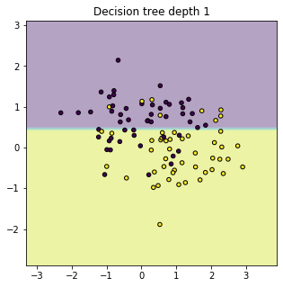

```python
# Plotting decision regions
x_min, x_max = X[:, 0].min() - 1, X[:, 0].max() + 1
y_min, y_max = X[:, 1].min() - 1, X[:, 1].max() + 1
xx, yy = np.meshgrid(np.arange(x_min, x_max, 0.1), np.arange(y_min, y_max, 0.1))
f, axarr = plt.subplots(1, 1, sharex='col', sharey='row', figsize=(5, 5))
Z = clf.predict(np.c_[xx.ravel(), yy.ravel()])
Z = Z.reshape(xx.shape)
axarr.contourf(xx, yy, Z, alpha=0.4)
axarr.scatter(X[:, 0], X[:, 1], c=y, s=20, edgecolor='k')
axarr.set_title('Decision tree depth {0}'.format(dt))
```

```python
dt = 2
clf = DecisionTreeClassifier(max_depth=dt)

clf.fit(X, y)
```

```
DecisionTreeClassifier(class_weight=None, criterion='gini', max_depth=2,
                       max_features=None, max_leaf_nodes=None,
                       min_impurity_decrease=0.0, min_impurity_split=None,
                       min_samples_leaf=1, min_samples_split=2,
                       min_weight_fraction_leaf=0.0, presort=False,
                       random_state=None, splitter='best')
```

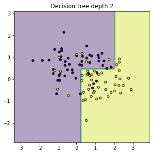

```python
# Plotting decision regions
x_min, x_max = X[:, 0].min() - 1, X[:, 0].max() + 1
y_min, y_max = X[:, 1].min() - 1, X[:, 1].max() + 1
xx, yy = np.meshgrid(np.arange(x_min, x_max, 0.1),
                     np.arange(y_min, y_max, 0.1))

f, axarr = plt.subplots(1, 1, sharex='col', sharey='row', figsize=(5, 5))

Z = clf.predict(np.c_[xx.ravel(), yy.ravel()])
Z = Z.reshape(xx.shape)

axarr.contourf(xx, yy, Z, alpha=0.4)
axarr.scatter(X[:, 0], X[:, 1], c=y,
                              s=20, edgecolor='k')
axarr.set_title('Decision tree depth {0}'.format(dt))
```

```python
dt = 4
clf = DecisionTreeClassifier(max_depth=dt)

clf.fit(X, y)
```

```
DecisionTreeClassifier(class_weight=None, criterion='gini', max_depth=4,
                       max_features=None, max_leaf_nodes=None,
                       min_impurity_decrease=0.0, min_impurity_split=None,
                       min_samples_leaf=1, min_samples_split=2,
                       min_weight_fraction_leaf=0.0, presort=False,
                       random_state=None, splitter='best')
```

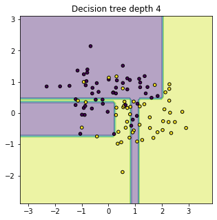

```python
# Plotting decision regions
x_min, x_max = X[:, 0].min() - 1, X[:, 0].max() + 1
y_min, y_max = X[:, 1].min() - 1, X[:, 1].max() + 1
xx, yy = np.meshgrid(np.arange(x_min, x_max, 0.1), np.arange(y_min, y_max, 0.1))
f, axarr = plt.subplots(1, 1, sharex='col', sharey='row', figsize=(5, 5))
Z = clf.predict(np.c_[xx.ravel(), yy.ravel()])
Z = Z.reshape(xx.shape)
axarr.contourf(xx, yy, Z, alpha=0.4)
axarr.scatter(X[:, 0], X[:, 1], c=y, s=20, edgecolor='k')
axarr.set_title('Decision tree depth {0}'.format(dt))
```

Decision tree boundaries are parallel or perpendicular to the feature axis.

## Complexity of Decision Trees

Decision trees are very easy to overfit. You can have a very deep decition tree that leads to pure leaves at the end. This means that the model has fit the training data with 100% accuracy.

Their are a couple of common strategies to prevent overfitting:

Collapsing nodes that contain little information.

Limiting the maximum depth of the tree.

Limiting the maximum number of leaves.

Requiring a minimum number of points in a node to keep splitting it.

Lets explore how tree depth affects the decision tree model performance.

```python
from sklearn.datasets import load_breast_cancer
from sklearn.model_selection import train_test_split

cancer = load_breast_cancer()
X_train, X_test, y_train, y_test = train_test_split(
cancer.data, cancer.target, stratify=cancer.target, random_state=42)
tree = DecisionTreeClassifier(random_state=0)
tree.fit(X_train, y_train)
print("Accuracy on training set: {:.3f}".format(tree.score(X_train, y_train)))
print("Accuracy on test set: {:.3f}".format(tree.score(X_test, y_test)))
```

```
Accuracy on training set: 1.000
Accuracy on test set: 0.937
```

Since the decision tree depth is not controlled, the tree can grow deep enough that we end up with pure leaves. The tree has essentially memorized the training data.

Lets now set the decision tree depth to 4.

```python
tree = DecisionTreeClassifier(max_depth=4, random_state=0)
tree.fit(X_train, y_train)
print("Accuracy on training set: {:.3f}%".format(100*tree.score(X_train, y_train)))
print("Accuracy on test set: {:.3f}%".format(100*tree.score(X_test, y_test)))
```

```
Accuracy on training set: 98.826%
Accuracy on test set: 95.105%
```

## Visualizing Decision Tree

```python
from sklearn.tree import export_graphviz
export_graphviz(tree, out_file="tree.dot", class_names=["malignant", "benign"],
feature_names=cancer.feature_names, impurity=False, filled=True)
```

```python
import graphviz
with open("tree.dot") as f:
    dot_graph = f.read()
display(graphviz.Source(dot_graph))
```

[figure not shown]

A decision tree is a great machine learning algorithm that is easily explained to nonexperts.

Even a decision tree with a depth of 4 can seem a bit overwhelming. Another great resource that we derive from the decision tree is feature importance. Feature importance is a measure of how important each feature is for the decision a tree makes.

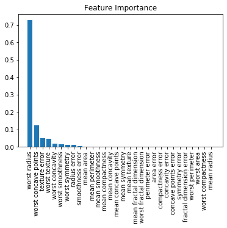

```python
# Calculate feature importances
importances = tree.feature_importances_
# Sort feature importances in descending order
indices = np.argsort(importances)[::-1]
# Rearrange feature names so they match the sorted feature importances
names = [cancer.feature_names[i] for i in indices]
# Create plot
plt.figure()
# Create plot title
plt.title("Feature Importance")
# Add bars
plt.bar(range(cancer.data.shape[1]), importances[indices])
# Add feature names as x-axis labels
plt.xticks(range(cancer.data.shape[1]), names, rotation=90)
# Show plot
plt.show()
```

We see that the most important feauture is also the feature that is used to split the tree at the top. This feature splits the two classes fairly well.

If a feature has a low value in feature*importance*, it doesn’t mean that this feature is uninformative. It only means that the feature was not picked up by the decision tree.

# Ensemble of Decision Trees

Ensembles are combinations of multiple machine learning model to create more powerful models. We will take a look at an ensemble model which has found a wide range of application in classification tasks: random forests.

As observed previously, one of the drawbacks of decision tree is that they tend to overfit. Random forests are oneway to address this problem.

A random forest is a collection of decision tree that are only slightly different from each other. Each tree will work well andoverfit the data in different ways, we can reduce the ovefitting by averaging the decision trees.

Their are a couple of different ways to build a random forest with slightly different trees:

randomly split training samples between trees

pass different features to each tree

# Analyzing Random Forests

Let’s apply a random forest consisting of five trees to the two_moons dataset we studied earlier.

```python
from sklearn.ensemble import RandomForestClassifier
from sklearn.datasets import make_moons

X, y = make_moons(n_samples=100, noise=0.25, random_state=3)
X_train, X_test, y_train, y_test = train_test_split(X, y, stratify=y,
random_state=42)

# we will be building 5 different decision trees
forest = RandomForestClassifier(n_estimators=5, random_state=2)

forest.fit(X_train, y_train)
```

```
RandomForestClassifier(bootstrap=True, class_weight=None, criterion='gini',
                       max_depth=None, max_features='auto', max_leaf_nodes=None,
                       min_impurity_decrease=0.0, min_impurity_split=None,
                       min_samples_leaf=1, min_samples_split=2,
                       min_weight_fraction_leaf=0.0, n_estimators=5,
                       n_jobs=None, oob_score=False, random_state=2, verbose=0,
                       warm_start=False)
```

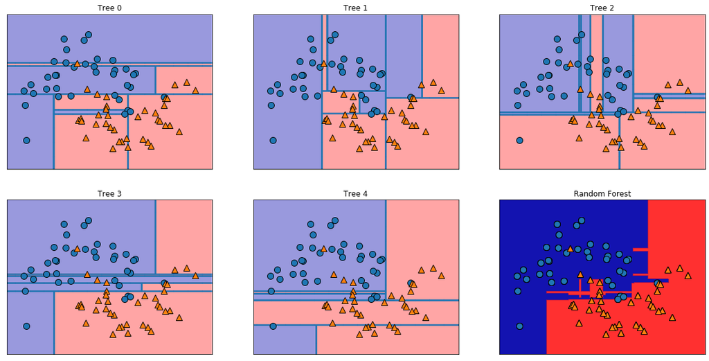

```python
fig, axes = plt.subplots(2, 3, figsize=(20, 10))
for i, (ax, tree) in enumerate(zip(axes.ravel(), forest.estimators_)):
    ax.set_title("Tree {}".format(i))
    mglearn.plots.plot_tree_partition(X_train, y_train, tree, ax=ax)
    mglearn.plots.plot_2d_separator(forest, X_train, fill=True, ax=axes[-1, -1],alpha=.4)
    axes[-1, -1].set_title("Random Forest")
    mglearn.discrete_scatter(X_train[:, 0], X_train[:, 1], y_train)
```

Each tree has learned different decision boundaries. In real world applications you might see hundreds of decision trees used for a random forest model.

Lets try to apply random forest model with 100 decision trees to the cancer dataset we saw earlier.

```python
X_train, X_test, y_train, y_test = train_test_split(
cancer.data, cancer.target, random_state=0)
forest = RandomForestClassifier(n_estimators=100, random_state=0)
forest.fit(X_train, y_train)
print("Accuracy on training set: {:.3f}%".format(100*forest.score(X_train, y_train)))
print("Accuracy on test set: {:.3f}%".format(100*forest.score(X_test, y_test)))
```

```
Accuracy on training set: 100.000%
Accuracy on test set: 97.203%
```

Similarly to decision tree, random forest also provides feature importance which are computed by aggregating the feature importance calculated from each decision tree. Typically the feature importance provided by random forest are more reliable than an individual decision tree.

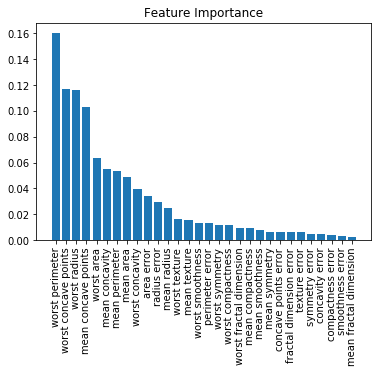

```python
# Calculate feature importances
importances = forest.feature_importances_
# Sort feature importances in descending order
indices = np.argsort(importances)[::-1]
# Rearrange feature names so they match the sorted feature importances
names = [cancer.feature_names[i] for i in indices]
# Create plot
plt.figure()
# Create plot title
plt.title("Feature Importance")
# Add bars
plt.bar(range(cancer.data.shape[1]), importances[indices])
# Add feature names as x-axis labels
plt.xticks(range(cancer.data.shape[1]), names, rotation=90)
# Show plot
plt.show()
```

As you can see that the random forest provides a different feature importance ranking than an individual tree. Because of its inherent randomness a random forest is forced to consider many different explanations.

# Gradient Boosted Tree

Gradient has recently become a very popular technique. It has been to win a wide variety of data science competitions.

Gradient boosting works by building trees in a serial manner, sequentially adding predictors to an ensemble, each one correcting its predecessor.

[figure not shown]

Source: [Source: Ensemble Learning — Bagging and Boosting](https://becominghuman.ai/ensemble-learning-bagging-and-boosting-d20f38be9b1e)

```python
from sklearn.ensemble import GradientBoostingClassifier

X_train, X_test, y_train, y_test = train_test_split(cancer.data, cancer.target, random_state=0)
gbrt = GradientBoostingClassifier(random_state=0, max_depth=1)
gbrt.fit(X_train, y_train)
print("Accuracy on training set: {:.3f}".format(gbrt.score(X_train, y_train)))
print("Accuracy on test set: {:.3f}".format(gbrt.score(X_test, y_test)))
```

```
Accuracy on training set: 0.991
Accuracy on test set: 0.972
```

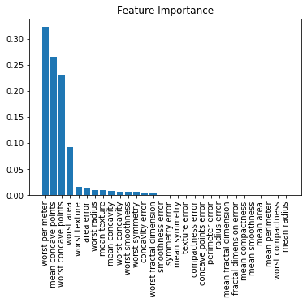

```python
# Calculate feature importances
importances = gbrt.feature_importances_
# Sort feature importances in descending order
indices = np.argsort(importances)[::-1]
# Rearrange feature names so they match the sorted feature importances
names = [cancer.feature_names[i] for i in indices]
# Create plot
plt.figure()
# Create plot title
plt.title("Feature Importance")
# Add bars
plt.bar(range(cancer.data.shape[1]), importances[indices])
# Add feature names as x-axis labels
plt.xticks(range(cancer.data.shape[1]), names, rotation=90)
# Show plot
plt.show()
```

The feature importances obtained from the gradient boosted trees are similar to the feature importances from random forests, though the gradient boosting completely ignored some of the features.